# Food at College

```r
# From your file menu (at the top of R-Studio) select:
# "Session -> Set working directory -> To source file location"
# Then play this chunk to get the data into R.
library(mosaic)
library(car)
library(DT)
library(pander)
library(readr)
library(dplyr)
library(tidyr)
food <- read_csv("../../Data/food.csv") #food.csv is in the Data folder...
```

### Background

During my two years as a full-time college student, I have experienced various employment situations, including being unemployed, fully employed, working part-time, and even balancing a full-time job with a side business. Throughout these experiences, I noticed that my GPA fluctuated depending on my workload and efforts to meet my family’s financial needs. This has sparked my interest in exploring how employment status affects the academic performance of full-time college students.

To investigate this, I will conduct a Kruskal-Wallis test on a dataset that includes information on the GPA of college students, their eating habits, cooking routines, demographic details, parental education levels, and, notably, their employment status. The focus of this study will be on analyzing whether students’ reported employment status correlates with their GPA outcomes.

Dataset Overview:

The dataset comes from a survey conducted with 125 college students. The survey collected data on various factors, including GPA, eating habits, cooking habits, demographic information, and employment status. For this analysis, we will specifically examine the relationship between employment status and the GPA that students reported, to determine whether employment status significantly impacts academic performance.

Through this study, I aim to better understand how balancing work and academic responsibilities may affect college students’ grades and to explore potential strategies for supporting students in similar situations.

## Raw data

Here is the dataset without any filters where you can see all the 125 surveys and all the questions asked.

```r
datatable(food, options=list(lengthMenu = c(2,10,30)), extensions="Responsive")
```

|  | GPA | weight | gender | breakfast | calories_chicken | calories_day | comfort_food | comfort_food_reasons | comfort_food_reasons_coded...9 | cook | comfort_food_reasons_coded...11 | cuisine | diet_current | diet_current_coded | drink | eating_changes | eating_changes_coded | eating_changes_coded1 | eating_out | employment | ethnic_food | exercise | father_education | father_profession | fav_cuisine | fav_cuisine_coded | fav_food | food_childhood | fries | … |
| --- | --- | --- | --- | --- | --- | --- | --- | --- | --- | --- | --- | --- | --- | --- | --- | --- | --- | --- | --- | --- | --- | --- | --- | --- | --- | --- | --- | --- | --- | --- |
| 1 | 2.4 | 187 | Male | Cereal | 430 |  | none | we dont have comfort | 9 | 2 | 9 |  | eat good and exercise | 1 | orange juice | eat faster | worse | 1 | 2-3 times | 3 | 1 | 1 | 5 | profesor | Arabic cuisine | 3 | 1 | rice and chicken | 2 | … |
| 2 | 3.654 | 155 | Female | Cereal | 610 | 3 | chocolate, chips, ice cream | Stress, bored, anger | 1 | 3 | 1 | 1 | I eat about three times a day with some snacks. I try to eat healthy but it doesn't always work out that- sometimes eat fast food and mainly eat at Laker/ Egan | 2 | soda | I eat out more than usual. | worse | 2 | 1-2 times | 2 | 4 | 1 | 2 | Self employed | Italian | 1 | 1 | chicken and biscuits, beef soup, baked beans | 1 | … |
| 3 | 3.3 | I'm not answering this. | Female | Cereal | 720 | 4 | frozen yogurt, pizza, fast food | stress, sadness | 1 | 1 | 1 | 3 | toast and fruit for breakfast, salad for lunch, usually grilled chicken and veggies (or some variation) for dinner | 3 | orange juice | sometimes choosing to eat fast food instead of cooking simply for convenience | worse | 3 | 1-2 times | 3 | 5 | 2 | 2 | owns business | italian | 1 | 3 | mac and cheese, pizza, tacos | 1 | … |
| 4 | 3.2 | Not sure, 240 | Female | Cereal | 430 | 3 | Pizza, Mac and cheese, ice cream | Boredom | 2 | 2 | 2 | 2 | College diet, cheap and easy foods most nights. Weekends traditionally, cook better homemade meals | 2 | soda | Accepting cheap and premade/store bought foods | worse | 3 | 1-2 times | 3 | 5 | 3 | 2 | Mechanic | Turkish | 3 | 1 | Beef stroganoff, tacos, pizza | 2 | … |
| 5 | 3.5 | 190 | Female | Cereal | 720 | 2 | Ice cream, chocolate, chips | Stress, boredom, cravings | 1 | 1 | 1 | 2 | I try to eat healthy but often struggle because of living on campus. I still try to keep the choices I do make balanced with fruits and vegetables and limit the sweats. | 2 | soda | I have eaten generally the same foods but I do find myself eating the same food frequently due to what I have found I like from egan and the laker. | the same | 4 | 1-2 times | 2 | 4 | 1 | 4 | IT | Italian | 1 | 3 | Pasta, chicken tender, pizza | 1 | … |
| 6 | 2.25 | 190 | Female | Cereal | 610 | 3 | Candy, brownies and soda. | None, i don't eat comfort food. I just eat when i'm hungry. | 4 | 3 | 4 |  | My current diet is terrible. I barely have time to eat a meal in a day. When i do eat it's mostly not healthy. | 2 | soda | Eating rice everyday. Eating less homemade food. | worse | 3 | Never | 3 | 4 | 2 | 1 | Taxi Driver | African | 6 | 3 | Fries, plaintain &amp; fried fish | 1 | … |
| 7 | 3.8 | 180 | Male | Cereal | 610 | 3 | Chocolate, ice cream, french fries, pretzels | stress, boredom | 1 | 2 | 1 | 1 | I eat a lot of chicken and broccoli for dinner, and usually tuna sandwiches for lunch. | 3 | orange juice | I started eating a lot less and healthier because I wasn't playing sports year round anymore. | better | 5 | 1-2 times | 3 | 5 | 1 | 4 | Assembler | Thai | 4 | 1 | grilled chicken, hamburgers | 1 | … |
| 8 | 3.3 | 137 | Female | Cereal | 720 | 3 | Ice cream, cheeseburgers, chips. | I eat comfort food when im stressed out from school(finals week), when I`m sad, or when i am dealing with personal family issues. | 1 | 3 | 1 | 1 | I eat a very healthy diet. Ocassionally, i will eat out and get unhealthy food. | 1 | soda | Freshmen year i ate very unhealthy, but now it is much healthier because of self control. | better | 5 | 1-2 times | 2 | 2 | 2 | 3 | Business guy | Anything american style. | 5 | 1 | chicken, cheesey potatoes, and hot dogs | 1 | … |
| 9 | 3.3 | 180 | Female | Cereal | 430 |  | Donuts, ice cream, chips | Boredom | 2 | 3 | 2 | 1 | I eat whatever I want in moderation. | 1 | orange juice | I snack less | better | 8 | every day | 2 | 5 |  | 5 | High School Principal | Seafood | 1 | 3 | Shrimp, spaghetti | 1 | … |
| 10 | 3.3 | 125 | Female | Cereal | 430 | 3 | Mac and cheese, chocolate, and pasta | Stress, anger and sadness | 1 | 3 | 1 | 1 | I eat healthy all the time when possible. I treat myself occasionally. I don't really like the greasy meals, if anything I would eat sweets over the greasy meals. | 1 | orange juice | I cook a lot of my own foods back at home so not being able to cook my own healthy choices. I eat more carbs than normal when I'm at college due to the choices given in the cafe. | worse | 3 | 2-3 times | 3 | 5 | 1 | 5 | commissioner of erie county | Italian | 1 | 1 | Pasta, Eggs, Pancakes | 1 | … |

[output cut: 115 more lines]

### Filtered data

Now we filtered the data to only show GPA and employment status, we also removed 13 rows where students did not respond to the questions, or responded incorrectly.

```r
food2 <- food %>%
  group_by(employment) %>%
  mutate(
    id = row_number(),
  employment = case_when(
    employment == 1 ~ "Full time",
    employment == 2 ~ "Part time",
    employment == 3 ~ "Unemployed"),
  GPA = as.numeric(gsub("^(Personal|Unknown)$", NA, GPA))) %>%
 filter(!is.na(employment) & !is.na(GPA))

food2 <- select(food2, c(GPA, employment))

datatable(food2, options=list(lengthMenu = c(3,10,30)), extensions="Responsive")
```

|  | GPA | employment |
| --- | --- | --- |
| 1 | 2.4 | Unemployed |
| 2 | 3.654 | Part time |
| 3 | 3.3 | Unemployed |
| 4 | 3.2 | Unemployed |
| 5 | 3.5 | Part time |
| 6 | 2.25 | Unemployed |
| 7 | 3.8 | Unemployed |
| 8 | 3.3 | Part time |
| 9 | 3.3 | Part time |
| 10 | 3.3 | Unemployed |

[output cut: 102 more lines]

### Employment status

```r
Full_time <- filter(food2, employment == "Full time")
Part_time <- filter(food2, employment == "Part time")
Unemployed <- filter(food2, employment == "Unemployed")

combined <- bind_rows(
  Full_time %>% mutate(employment = "Full time"),
  Part_time %>% mutate(employment = "Part time"),
  Unemployed %>% mutate(employment = "Unemployed")
) %>%
  mutate(id = row_number())

food2_wide <- combined %>%
  pivot_wider(
    names_from = employment,
    values_from = GPA
  )

GPA_table <- select(food2_wide, c(`Full time`, `Part time`, Unemployed))
datatable(GPA_table, options = list(pageLength = 10))
```

|  | Full time | Part time | Unemployed |
| --- | --- | --- | --- |
| 1 | 3.5 | 3.654 | 2.4 |
| 2 | 3.5 | 3.5 | 3.3 |
| 3 |  | 3.3 | 3.2 |
| 4 |  | 3.3 | 2.25 |
| 5 |  | 3.904 | 3.8 |
| 6 |  | 3.6 | 3.3 |
| 7 |  | 4 | 3.4 |
| 8 |  | 3.4 | 3.1 |
| 9 |  | 3.3 | 3.6 |
| 10 |  | 3.87 | 2.2 |

[output cut: 48 more lines]

We can see in the table above that only 2 students are full time employed, the other 110 students are either part time employed or unemployed.

### Hypothesis and significance level

Before proceeding to do the Kruskal test, we want to show what our hypothesis are:

$$H_0: The\ distribution\ of\ GPA\ is\ the\ same\ across\ all\
employment\ statuses\ (Full time, Part time, and\ Unemployed)$$
$$H_a: At\ least\ one\ of\ the\ employment\ statuses\ (Full time, Part
time, or\ Unemployed)\ has\ a\ significantly\ different\ GPA\
distribution\ from\ the\ others.$$
To test the hypothesis, we set the significance level α at 0.05. The null hypothesis (H₀) states that there is no significant difference in GPA distributions across the employment status groups (Full time, Part time, Unemployed), meaning the medians of GPA are equal. The alternative hypothesis (H₁) suggests that at least one of the groups has a different GPA distribution. If the p-value from the Kruskal-Wallis test is less than 0.05, we reject the null hypothesis, concluding that there is a significant difference in GPA between the groups. If the p-value is greater than or equal to 0.05, we fail to reject the null hypothesis, meaning there is no sufficient evidence to claim that employment status affects GPA.

### Kruskal test

```r
kruskal.test(list(food2_wide$`Full time`, food2_wide$`Part time`, food2_wide$Unemployed))
```

```
##
##  Kruskal-Wallis rank sum test
##
## data:  list(food2_wide$`Full time`, food2_wide$`Part time`, food2_wide$Unemployed)
## Kruskal-Wallis chi-squared = 1.3575, df = 2, p-value = 0.5073
```

Kruskal-Wallis Test Results: Test statistic = 1.3575, df = 2, p-value = 0.5073. The p-value is greater than 0.05, so we fail to reject the null hypothesis.

Interpretation: The null hypothesis states that there is no significant difference in GPA between the three groups (Full time, Part time, Unemployed). Since the p-value is greater than 0.05, we conclude that there is no significant difference in GPAs across the employment statuses.

### Summary table

```r
favstats(GPA ~ employment, data = food2) %>%
  pander(caption = "Students GPA Summaries by Employment Statuses")
```

| employment | min | Q1 | median | Q3 | max | mean | sd | n | missing |
| --- | --- | --- | --- | --- | --- | --- | --- | --- | --- |
| Full time | 3.5 | 3.5 | 3.5 | 3.5 | 3.5 | 3.5 | 0 | 2 | 0 |
| Part time | 2.6 | 3.225 | 3.5 | 3.7 | 4 | 3.479 | 0.3324 | 58 | 0 |
| Unemployed | 2.2 | 3 | 3.45 | 3.7 | 4 | 3.36 | 0.452 | 52 | 0 |

### GPA by Employment Status

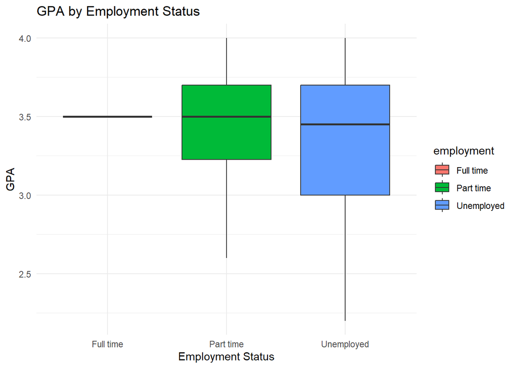

```r
combined_long <- bind_rows(
  Full_time %>% mutate(employment = "Full time"),
  Part_time %>% mutate(employment = "Part time"),
  Unemployed %>% mutate(employment = "Unemployed")
)


ggplot(combined_long, aes(x = employment, y = GPA, fill = employment)) +
  geom_boxplot() +
  labs(title = "GPA by Employment Status", y = "GPA", x = "Employment Status") +
  theme_minimal()
```

The boxplot above shows that the GPA for both Full-time and Part-time employment statuses is around 3.5, while the GPA for the Unemployed group is slightly lower, but the difference is not statistically significant.

### Conclusion

Based on our test, summary table, and boxplot, we conclude that the number of hours spent working—whether full-time, part-time, or not working—does not significantly impact a student’s GPA. In other words, employment status does not appear to be a valid explanation for differences in academic performance.